# CPS305 Fall 2019

## Lab 1 Report

## Nathalie Ng, Std ID 500921963

12 September 2019

# Introduction and Overall Comments

The lab instructions could be a little more clear as it took me a really long time to completely understand what my code was supposed to do. After understanding the objective of the program though, I thought it was good and engaging.

## Solution for exercise 1

```
String                       Score    Epoch
mettpinxvmjs cqodehrvsxymitp 10.714286 100
methinkxvmjs cqodehrvsxymitp 25.000000 200
methinks mjs cqodehrvsxymitp 32.142857 300
methinks ijs cqodehrvsxymitp 35.714286 400
methinks it  cqodehrvsxymitp 42.857143 500
methinks it is like vsxymitp 71.428571 600
methinks it is like a weastp 92.857143 700
methinks it is like a weasel 100.000000 729
```

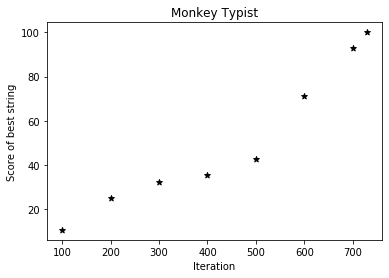

```python
import random
import matplotlib.pyplot as plt

def generate(lenS, lenA, alphabet):
#generate random string by getting a random integer and matching the integer to a letter in the alphabet
    string = ""
    for i in range(lenS):
        a = random.randint(0,lenA-1)
        string = string + alphabet[a]
    return string

def calcScore(newstr, target):
#generate score for similarity of generated string and given string
    similar = 0
    for i in range(len(target)):
        if newstr[i] == target[i]:
            similar = similar + 1
    return similar/len(target)*100


def monkeyTypist():
    #creating the scatter plot
    x = []
    y = []
    plt.xlabel('Iteration')
    plt.ylabel('Score of best string')
    plt.title("Monkey Typist")

    target = list("methinks it is like a weasel")
    lenS = len(target)
    alphabet = list("abcdefghijklmnopqrstuvwxyz ")
    lenA = len(alphabet)
    epoch = 0
    bestStr = generate(lenS, lenA, alphabet)
    bestScore = calcScore(bestStr, target)
    print("String                       Score    Epoch")
    newScore = 0
    while bestScore < 100:
        if bestScore==100:
            break
        newStr = bestStr
        if newScore<=bestScore:
            #to check the first incorrect letter if the entire string is still incorrect
            for i in range(len(newStr)):
                if newStr[i] != target[i]:
                    #if the letters don't match, it will generate a new letter to replace the old letter
                    a = random.randint(0, lenA - 1)
                    newLetter = alphabet[a]
                    strList = list(newStr)
                    strList[i] = newLetter
                    strApp = ''.join(strList)
                    newStr = strApp
                    epoch = epoch + 1
                    break
            newScore = calcScore(newStr, target)
        if newScore > bestScore:
            bestScore = newScore
            bestStr = newStr
        if epoch%100==0:
            print("%s %f %d" % ("".join(bestStr), bestScore, epoch))
            #appending to list for graph values
            x.append(epoch)
            y.append(bestScore)

    #print and append the final score and epoch values to print at 100%, and plot at 100%
    print("%s %f %d" % ("".join(bestStr), bestScore, epoch))
    x.append(epoch)
    y.append(bestScore)
    plt.scatter(x,y, label = 'graph', color = 'k', marker = '*')
    plt.show()

monkeyTypist()
```

**Discussion of the Results**

The first line of the results show the generation of the random string after 100 tries of getting it closer to the target. This shows that a new string was successfully randomly generated with the generate function. We can see that every 100 times the program runs through the while loop, it will display the best result in that set. We can see in the colomn "Epoch" how many times in total the program has gone through the while loop to produce results closer to the target string. The program goes letter by letter starting from the left to get closer to the target string, with the final result of 100% similarity usually ranging between 300-900 tries. The scatter plot shows an upwards direction of increase to show that with every iteration through the while loop, the string will get closer and closer to the target.